# **DataSpace Work: LSD Consumption**

**Cap 1:** Explanatory Data Analysis  
*Piero Cavalcanti - s252117*

# Classes, Libraries, and Instances for coding

#### Libraries

```python
# -*- coding: utf-8 -*-

print (__doc__)

from mpl_toolkits.mplot3d import Axes3D
from mlxtend.plotting import plot_decision_regions
from PIL import Image
from sklearn import preprocessing
from sklearn.model_selection import train_test_split
from sklearn.naive_bayes import GaussianNB
#from mlxtend.plotting import plot_decision_regions
from sklearn.decomposition import PCA
import numpy as np
import matplotlib.pyplot as plt
import matplotlib.colors as colours
import matplotlib.image as mpimg
import glob
import os
from random import randrange
from sys import getsizeof

import pandas as pd
import numpy as np
import matplotlib.pyplot as plt
from mpl_toolkits.mplot3d import Axes3D
from sklearn import datasets, svm
from sklearn.ensemble import RandomForestClassifier
from sklearn.model_selection import train_test_split
from sklearn.decomposition import PCA
from sklearn.metrics import accuracy_score, roc_auc_score, log_loss
from matplotlib.colors import Normalize
from sklearn.preprocessing import StandardScaler
from sklearn import decomposition
from sklearn.tree import export_graphviz
import pydot
from sklearn.model_selection import StratifiedShuffleSplit
from sklearn.model_selection import GridSearchCV
import random
import seaborn as sns
import csv
import time

from sklearn.naive_bayes import GaussianNB
from sklearn.svm import SVC
from sklearn.datasets import load_digits
from sklearn.model_selection import learning_curve
from sklearn.model_selection import ShuffleSplit


from sklearn.linear_model import LogisticRegression, LinearRegression
from sklearn import metrics

from sklearn.neighbors import KNeighborsClassifier

import matplotlib.pyplot as plt
import numpy as np
from sklearn import datasets, linear_model
from sklearn.metrics import mean_squared_error, r2_score

from scipy import stats
```

```
Automatically created module for IPython interactive environment
```

#### Constraint Definition

```python
input_file = "C:/Users/pcava/Desktop/Università/2_I_DataSpaces/tesina/DrugConsumption/dc.csv"
```

#### Function Definition

- *function*: domain_features()

helpful function to plot the number of different unique value for each feature (the *domain*)

```python
def domain_features(df,features):
    for feature in features:
        print("Number of different value for '",feature,"': " , len(df[feature].unique()))
```

# Data Exploration

*“Torture the data, and it will confess to anything.”*

Exploratory Data Analysis (EDA) is the process of visualizing and analyzing data to extract insights from it. In other words, EDA is the process of summarizing important characteristics of data in order to gain better understanding of the dataset.

### Load the dataset

we are collecting the datas into a *pandas* **Dataframe** that gives you the possibility to work with great flexibility and enjoying the huge amount of methods that pandas provides for manipulate and analyze the datasets

```python
#charging datas from the data file
data = pd.read_csv("drug_consumption.data.txt", sep=",", header=None)
pd.options.display.max_columns = None
# row and column number
data.columns = ["ID", "Age","Gender","Education", "Country","Ethnicity", "Nscore","Escore","Oscore","Ascore","Cscore","Impulsive", "SS","Alcohol","Amphet","Amyl","Benzos","Caff","Cannabis","Choc" , "Coke", "Crack", "Ecstasy", "Heroin", "Ketamine", "Legalh", "LSD", "Meth", "Mushrooms", "Nicotine", "Semer", "VSA"]
print("Columns:",len(data.columns))
print("Rows:",data.ID.count())
```

```
Columns: 32
Rows: 1885
```

Let's get an idea of our dataset: What we can predict here is about the *course of dimensionality*,that can be defined by the situation where basically with an enormous number of features and not enough representative samples, model performance starts getting affected often leading to overfitting. The rule of thumb in this situation is to own a number of istances that is, at least, one order of magnitude greater than the number of features, that here are labelled as "Columns"

### First look at the Dataset

By using the *pandas* interfaces function, we can collect some information about dimensions, types, and others details on the Dataset we choosed.

Firstly, Generate an understandable copy of dataset, replacing the numerical values with the referred definitions (for particular values used in visualization).

```python
#Generate the Categorical definition, instead of numerical
#charging datas from the data file
data_str = pd.read_csv("drug_consumption_str.data.txt", sep=",", header=None)
# row and column
data_str.columns = ["ID", "Age","Gender","Education", "Country","Ethnicity", "Nscore","Escore","Oscore","Ascore","Cscore","Impulsive", "SS","Alcohol","Amphet","Amyl","Benzos","Caff","Cannabis","Choc" , "Coke", "Crack", "Ecstasy", "Heroin", "Ketamine", "Legalh", "LSD", "Meth", "Mushrooms", "Nicotine", "Semer", "VSA"]
```

There we have a *preview* of our dataset, to get a first look on categories and example of instances:

```python
#preview of Dataset
data.head()
```

|  | ID | Age | Gender | Education | Country | Ethnicity | Nscore | Escore | Oscore | Ascore | Cscore | Impulsive | SS | Alcohol | Amphet | Amyl | Benzos | Caff | Cannabis | Choc | Coke | Crack | Ecstasy | Heroin | Ketamine | Legalh | LSD | Meth | Mushrooms | … |
| --- | --- | --- | --- | --- | --- | --- | --- | --- | --- | --- | --- | --- | --- | --- | --- | --- | --- | --- | --- | --- | --- | --- | --- | --- | --- | --- | --- | --- | --- | --- |
| 0 | 1 | 0.49788 | 0.48246 | -0.05921 | 0.96082 | 0.12600 | 0.31287 | -0.57545 | -0.58331 | -0.91699 | -0.00665 | -0.21712 | -1.18084 | 5 | 2 | 0 | 2 | 6 | 0 | 5 | 0 | 0 | 0 | 0 | 0 | 0 | 0 | 0 | 0 | … |
| 1 | 2 | -0.07854 | -0.48246 | 1.98437 | 0.96082 | -0.31685 | -0.67825 | 1.93886 | 1.43533 | 0.76096 | -0.14277 | -0.71126 | -0.21575 | 5 | 2 | 2 | 0 | 6 | 4 | 6 | 3 | 0 | 4 | 0 | 2 | 0 | 2 | 3 | 0 | … |
| 2 | 3 | 0.49788 | -0.48246 | -0.05921 | 0.96082 | -0.31685 | -0.46725 | 0.80523 | -0.84732 | -1.62090 | -1.01450 | -1.37983 | 0.40148 | 6 | 0 | 0 | 0 | 6 | 3 | 4 | 0 | 0 | 0 | 0 | 0 | 0 | 0 | 0 | 1 | … |
| 3 | 4 | -0.95197 | 0.48246 | 1.16365 | 0.96082 | -0.31685 | -0.14882 | -0.80615 | -0.01928 | 0.59042 | 0.58489 | -1.37983 | -1.18084 | 4 | 0 | 0 | 3 | 5 | 2 | 4 | 2 | 0 | 0 | 0 | 2 | 0 | 0 | 0 | 0 | … |
| 4 | 5 | 0.49788 | 0.48246 | 1.98437 | 0.96082 | -0.31685 | 0.73545 | -1.63340 | -0.45174 | -0.30172 | 1.30612 | -0.21712 | -0.21575 | 4 | 1 | 1 | 0 | 6 | 3 | 6 | 0 | 0 | 1 | 0 | 0 | 1 | 0 | 0 | 2 | … |

```python
#preview of uncoded dataset
data_str.head()
```

|  | ID | Age | Gender | Education | Country | Ethnicity | Nscore | Escore | Oscore | Ascore | Cscore | Impulsive | SS | Alcohol | Amphet | Amyl | Benzos | Caff | Cannabis | Choc | Coke | Crack | Ecstasy | Heroin | Ketamine | Legalh | LSD | Meth | Mushrooms | … |
| --- | --- | --- | --- | --- | --- | --- | --- | --- | --- | --- | --- | --- | --- | --- | --- | --- | --- | --- | --- | --- | --- | --- | --- | --- | --- | --- | --- | --- | --- | --- |
| 0 | 1 | 35-44 | Female | Professional certificate/ diploma | UK | Mixed-White/Asian | 0.31287 | -0.57545 | -0.58331 | -0.91699 | -0.00665 | -0.21712 | -1.18084 | 5 | 2 | 0 | 2 | 6 | 0 | 5 | 0 | 0 | 0 | 0 | 0 | 0 | 0 | 0 | 0 | … |
| 1 | 2 | 25-34 | Male | Doctorate degree | UK | White | -0.67825 | 1.93886 | 1.43533 | 0.76096 | -0.14277 | -0.71126 | -0.21575 | 5 | 2 | 2 | 0 | 6 | 4 | 6 | 3 | 0 | 4 | 0 | 2 | 0 | 2 | 3 | 0 | … |
| 2 | 3 | 35-44 | Male | Professional certificate/ diploma | UK | White | -0.46725 | 0.80523 | -0.84732 | -1.62090 | -1.01450 | -1.37983 | 0.40148 | 6 | 0 | 0 | 0 | 6 | 3 | 4 | 0 | 0 | 0 | 0 | 0 | 0 | 0 | 0 | 1 | … |
| 3 | 4 | 18-24 | Female | Masters degree | UK | White | -0.14882 | -0.80615 | -0.01928 | 0.59042 | 0.58489 | -1.37983 | -1.18084 | 4 | 0 | 0 | 3 | 5 | 2 | 4 | 2 | 0 | 0 | 0 | 2 | 0 | 0 | 0 | 0 | … |
| 4 | 5 | 35-44 | Female | Doctorate degree | UK | White | 0.73545 | -1.63340 | -0.45174 | -0.30172 | 1.30612 | -0.21712 | -0.21575 | 4 | 1 | 1 | 0 | 6 | 3 | 6 | 0 | 0 | 1 | 0 | 0 | 1 | 0 | 0 | 2 | … |

At first look, it is possible to retrieve some usefull information about out dataset:

1. Excluding the ID, there are almost two kind of features related to our dataset:
   - the first one are categorical and encoded (in the first table we can see the coded categories, where one real number represent one particular categorical value). As we will see, the numbers selected for representing the categories are not randoms. In the second table there the "explained" categories (all but some psicological scores that are meaningless for human beings)
   - the other ones are the "Addiction" classes and are coded in 7 element (from 0 to 6), representing, as we will see, a grade of addiction to the named substance that goes from Not User (0) at "User in the last days" (6). Its look perfect as labels for Multiclass Classification problem.

Here, a simple block of code for null-value detection:

```python
# check for null values in the dataset
print(("Some" if data.isnull().values.any() else "No")  + " null/missing values in the dataset.")
```

```
No null/missing values in the dataset.
```

## Dataset General Information

From the official **UCI Dataset Repository**, we have a deep description of our dataset

**Abstract**: Classify type of drug consumer by personality data  
**Data Set Characteristics**: Multivariate  
**Number of Instances**: 1885  
**Attribute Characteristics**: Real  
**Number of Attributes**:32  
Associated Tasks:**Classification**  
**Missing Values?** N/A  
**Number of Web Hits**: 77254

### Data Set Information:

Database contains records for **1885 respondents**. For each respondent **12 attributes are known**: Personality measurements which include NEO-FFI-R (neuroticism, extraversion, openness to experience, agreeableness, and conscientiousness), BIS-11 (impulsivity), and ImpSS (sensation seeking), level of education, age, gender, country of residence and ethnicity. All input attributes are originally categorical and are quantified. After quantification values of all input features can be considered as real-valued. In addition, participants were questioned concerning their **use of 18 legal and illegal drugs** (alcohol, amphetamines, amyl nitrite, benzodiazepine, cannabis, chocolate, cocaine, caffeine, crack, ecstasy, heroin, ketamine, legal highs, LSD, methadone, mushrooms, nicotine and volatile substance abuse and one fictitious drug (Semeron) which was introduced to identify over-claimers. For each drug they have to select one of the answers: never used the drug, used it over a decade ago, or in the last decade, year, month, week, or day. Database contains **18 classification problems**. Each of independent label variables contains seven classes: **"Never Used", "Used over a Decade Ago", "Used in Last Decade", "Used in Last Year", "Used in Last Month", "Used in Last Week", and "Used in Last Day".**

### Problem which can be solved

- *Seven class classifications for each drug separately.*
- *Problem can be transformed to binary classification by union of part of classes into one new class. For example, "Never Used", "Used over a Decade Ago" form class "Non-user" and all other classes form class "User".*
- *The best binarization of classes for each attribute.*
- *Evaluation of risk to be drug consumer for each drug.*

### Features Examination

#### Features Description

1. **ID** is number of record in original database. Cannot be related to participant. It can be used for reference only.
2. **Age** (Real) is age of participant and has one of the values:  
   Value Meaning Cases Fraction  
   -0.95197 18-24 643 34.11%  
   -0.07854 25-34 481 25.52%  
   0.49788 35-44 356 18.89%  
   1.09449 45-54 294 15.60%  
   1.82213 55-64 93 4.93%  
   2.59171 65+ 18 0.95%  
   Descriptive statistics  
   Min Max Mean Std.dev.  
   -0.95197 2.59171 0.03461 0.87813
3. **Gender** (Real) is gender of participant:  
   Value Meaning Cases Fraction  
   0.48246 Female 942 49.97%  
   -0.48246 Male 943 50.03%  
   Descriptive statistics  
   Min Max Mean Std.dev.  
   -0.48246 0.48246 -0.00026 0.48246
4. **Education** (Real) is level of education of participant and has one of the values:  
   Value Meaning Cases Fraction  
   -2.43591 Left school before 16 years 28 1.49%  
   -1.73790 Left school at 16 years 99 5.25%  
   -1.43719 Left school at 17 years 30 1.59%  
   -1.22751 Left school at 18 years 100 5.31%  
   -0.61113 Some college or university, no certificate or degree 506 26.84%  
   -0.05921 Professional certificate/ diploma 270 14.32%  
   0.45468 University degree 480 25.46%  
   1.16365 Masters degree 283 15.01%  
   1.98437 Doctorate degree 89 4.72%  
   Descriptive statistics  
   Min Max Mean Std.dev.  
   -2.43591 1.98437 -0.00379 0.95004
5. **Country** (Real) is country of current residence of participant and has one of the values:  
   Value Meaning Cases Fraction  
   -0.09765 Australia 54 2.86%  
   0.24923 Canada 87 4.62%  
   -0.46841 New Zealand 5 0.27%  
   -0.28519 Other 118 6.26%  
   0.21128 Republic of Ireland 20 1.06%  
   0.96082 UK 1044 55.38%  
   -0.57009 USA 557 29.55%  
   Descriptive statistics  
   Min Max Mean Std.dev.  
   -0.57009 0.96082 0.35554 0.70015
6. **Ethnicity** (Real) is ethnicity of participant and has one of the values:  
   Value Meaning Cases Fraction  
   -0.50212 Asian 26 1.38%  
   -1.10702 Black 33 1.75%  
   1.90725 Mixed-Black/Asian 3 0.16%  
   0.12600 Mixed-White/Asian 20 1.06%  
   -0.22166 Mixed-White/Black 20 1.06%  
   0.11440 Other 63 3.34%  
   -0.31685 White 1720 91.25%  
   Descriptive statistics  
   Min Max Mean Std.dev.  
   -1.10702 1.90725 -0.30958 0.16618
7. **Nscore** (Real) is NEO-FFI-R Neuroticism. Possible values are presented in table below:  
   Nscore Cases Value Nscore Cases Value Nscore Cases Value  
   12 1 -3.46436 29 60 -0.67825 46 67 1.02119  
   13 1 -3.15735 30 61 -0.58016 47 27 1.13281  
   14 7 -2.75696 31 87 -0.46725 48 49 1.23461  
   15 4 -2.52197 32 78 -0.34799 49 40 1.37297  
   16 3 -2.42317 33 68 -0.24649 50 24 1.49158  
   17 4 -2.34360 34 76 -0.14882 51 27 1.60383  
   18 10 -2.21844 35 69 -0.05188 52 17 1.72012  
   19 16 -2.05048 36 73 0.04257 53 20 1.83990  
   20 24 -1.86962 37 67 0.13606 54 15 1.98437  
   21 31 -1.69163 38 63 0.22393 55 11 2.12700  
   22 26 -1.55078 39 66 0.31287 56 10 2.28554  
   23 29 -1.43907 40 80 0.41667 57 6 2.46262  
   24 35 -1.32828 41 61 0.52135 58 3 2.61139  
   25 56 -1.19430 42 77 0.62967 59 5 2.82196  
   26 57 -1.05308 43 49 0.73545 60 2 3.27393  
   27 65 -0.92104 44 51 0.82562  
   28 70 -0.79151 45 37 0.91093  
   Descriptive statistics  
   Min Max Mean Std.dev.  
   -3.46436 3.27393 0.00004 0.99808
8. **Escore** (Real) is NEO-FFI-R Extraversion. Possible values are presented in table below:  
   Escore Cases Value Escore Cases Value Escore Cases Value  
   16 2 -3.27393 31 55 -1.23177 45 91 0.80523  
   18 1 -3.00537 32 52 -1.09207 46 69 0.96248  
   19 6 -2.72827 33 77 -0.94779 47 64 1.11406  
   20 3 -2.53830 34 68 -0.80615 48 62 1.28610  
   21 3 -2.44904 35 58 -0.69509 49 37 1.45421  
   22 8 -2.32338 36 89 -0.57545 50 25 1.58487  
   23 5 -2.21069 37 90 -0.43999 51 34 1.74091  
   24 9 -2.11437 38 106 -0.30033 52 21 1.93886  
   25 4 -2.03972 39 107 -0.15487 53 15 2.12700  
   26 21 -1.92173 40 130 0.00332 54 10 2.32338  
   27 23 -1.76250 41 116 0.16767 55 9 2.57309  
   28 23 -1.63340 42 109 0.32197 56 2 2.85950  
   29 32 -1.50796 43 105 0.47617 58 1 3.00537  
   30 38 -1.37639 44 103 0.63779 59 2 3.27393  
   Descriptive statistics  
   Min Max Mean Std.dev.  
   -3.27393 3.27393 -0.00016 0.99745
9. **Oscore** (Real) is NEO-FFI-R Openness to experience. Possible values are presented in table below:  
   Oscore Cases Value Oscore Cases Value Oscore Cases Value  
   24 2 -3.27393 38 64 -1.11902 50 83 0.58331  
   26 4 -2.85950 39 60 -0.97631 51 87 0.72330  
   28 4 -2.63199 40 68 -0.84732 52 87 0.88309  
   29 11 -2.39883 41 76 -0.71727 53 81 1.06238  
   30 9 -2.21069 42 87 -0.58331 54 57 1.24033  
   31 9 -2.09015 43 86 -0.45174 55 63 1.43533  
   32 13 -1.97495 44 101 -0.31776 56 38 1.65653  
   33 23 -1.82919 45 103 -0.17779 57 34 1.88511  
   34 25 -1.68062 46 134 -0.01928 58 19 2.15324  
   35 26 -1.55521 47 107 0.14143 59 13 2.44904  
   36 39 -1.42424 48 116 0.29338 60 7 2.90161  
   37 51 -1.27553 49 98 0.44585  
   Descriptive statistics  
   Min Max Mean Std.dev.  
   -3.27393 2.90161 -0.00053 0.99623
10. **Ascore** (Real) is NEO-FFI-R Agreeableness. Possible values are presented in table below:  
    Ascore Cases Value Ascore Cases Value Ascore Cases Value  
    12 1 -3.46436 34 42 -1.34289 48 104 0.76096  
    16 1 -3.15735 35 45 -1.21213 49 85 0.94156  
    18 1 -3.00537 36 62 -1.07533 50 68 1.11406  
    23 1 -2.90161 37 83 -0.91699 51 58 1.2861  
    24 2 -2.78793 38 82 -0.76096 52 39 1.45039  
    25 1 -2.70172 39 102 -0.60633 53 36 1.61108  
    26 7 -2.53830 40 98 -0.45321 54 36 1.81866  
    27 7 -2.35413 41 114 -0.30172 55 16 2.03972  
    28 8 -2.21844 42 101 -0.15487 56 14 2.23427  
    29 13 -2.07848 43 105 -0.01729 57 8 2.46262  
    30 18 -1.92595 44 118 0.13136 58 7 2.75696  
    31 24 -1.77200 45 112 0.28783 59 1 3.15735  
    32 30 -1.62090 46 100 0.43852 60 1 3.46436  
    33 34 -1.47955 47 100 0.59042  
    Descriptive statistics  
    Min Max Mean Std.dev.  
    -3.46436 3.46436 -0.00024 0.99744
11. **Cscore** (Real) is NEO-FFI-R Conscientiousness. Possible values are presented in table below:  
    Cscore Cases Value Cscore Cases Value Cscore Cases Value  
    17 1 -3.46436 32 39 -1.25773 46 113 0.58489  
    19 1 -3.15735 33 49 -1.13788 47 95 0.7583  
    20 3 -2.90161 34 55 -1.01450 48 95 0.93949  
    21 2 -2.72827 35 55 -0.89891 49 76 1.13407  
    22 5 -2.57309 36 69 -0.78155 50 47 1.30612  
    23 5 -2.42317 37 81 -0.65253 51 43 1.46191  
    24 6 -2.30408 38 77 -0.52745 52 34 1.63088  
    25 9 -2.18109 39 87 -0.40581 53 28 1.81175  
    26 13 -2.04506 40 97 -0.27607 54 27 2.04506  
    27 13 -1.92173 41 99 -0.14277 55 13 2.33337  
    28 25 -1.78169 42 105 -0.00665 56 8 2.63199  
    29 24 -1.64101 43 90 0.12331 57 3 3.00537  
    30 29 -1.51840 44 111 0.25953 59 1 3.46436  
    31 41 -1.38502 45 111 0.41594  
    Descriptive statistics  
    Min Max Mean Std.dev.  
    -3.46436 3.46436 -0.00039 0.99752
12. **Impulsive** (Real) is impulsiveness measured by BIS-11. Possible values are presented in table below:  
    Impulsiveness Cases Fraction  
    -2.55524 20 1.06%  
    -1.37983 276 14.64%  
    -0.71126 307 16.29%  
    -0.21712 355 18.83%  
    0.19268 257 13.63%  
    0.52975 216 11.46%  
    0.88113 195 10.34%  
    1.29221 148 7.85%  
    1.86203 104 5.52%  
    2.90161 7 0.37%  
    Descriptive statistics  
    Min Max Mean Std.dev.  
    -2.55524 2.90161 0.00721 0.95446
13. **SS** (Real) is sensation seeing measured by ImpSS. Possible values are presented in table below:  
    SS Cases Fraction  
    -2.07848 71 3.77%  
    -1.54858 87 4.62%  
    -1.18084 132 7.00%  
    -0.84637 169 8.97%  
    -0.52593 211 11.19%  
    -0.21575 223 11.83%  
    0.07987 219 11.62%  
    0.40148 249 13.21%  
    0.76540 211 11.19%  
    1.22470 210 11.14%  
    1.92173 103 5.46%  
    Descriptive statistics  
    Min Max Mean Std.dev.  
    -2.07848 1.92173 -0.00329 0.96370
14. **Alcohol** is class of alcohol consumption. It is output attribute with following distribution of classes.
15. **Amphet** is class of amphetamines consumption. It is output attribute with following distribution of classes.
16. **Amyl** is class of amyl nitrite consumption. It is output attribute with following distribution of classes.
17. **Benzos** is class of benzodiazepine consumption. It is output attribute with following distribution of classes:  
    Value Class Alcohol Amphet Amyl Benzos  
    Cases Fraction Cases Fraction Cases Fraction Cases Fraction  
    CL0 Never Used 34 1.80% 976 51.78% 1305 69.23% 1000 53.05%  
    CL1 Used over a Decade Ago 34 1.80% 230 12.20% 210 11.14% 116 6.15%  
    CL2 Used in Last Decade 68 3.61% 243 12.89% 237 12.57% 234 12.41%  
    CL3 Used in Last Year 198 10.50% 198 10.50% 92 4.88% 236 12.52%  
    CL4 Used in Last Month 287 15.23% 75 3.98% 24 1.27% 120 6.37%  
    CL5 Used in Last Week 759 40.27% 61 3.24% 14 0.74% 84 4.46%  
    CL6 Used in Last Day 505 26.79% 102 5.41% 3 0.16% 95 5.04%
18. **Caff** is class of caffeine consumption. It is output attribute with following distribution of classes.
19. **Cannabis** is class of cannabis consumption. It is output attribute with following distribution of classes.
20. **Choc** is class of chocolate consumption. It is output attribute with following distribution of classes.
21. **Coke** is class of cocaine consumption. It is output attribute with following distribution of classes:  
    Value Class Caff Cannabis Choc Coke  
    Cases Fraction Cases Fraction Cases Fraction Cases Fraction  
    CL0 Never Used 27 1.43% 413 21.91% 32 1.70% 1038 55.07%  
    CL1 Used over a Decade Ago 10 0.53% 207 10.98% 3 0.16% 160 8.49%  
    CL2 Used in Last Decade 24 1.27% 266 14.11% 10 0.53% 270 14.32%  
    CL3 Used in Last Year 60 3.18% 211 11.19% 54 2.86% 258 13.69%  
    CL4 Used in Last Month 106 5.62% 140 7.43% 296 15.70% 99 5.25%  
    CL5 Used in Last Week 273 14.48% 185 9.81% 683 36.23% 41 2.18%  
    CL6 Used in Last Day 1385 73.47% 463 24.56% 807 42.81% 19 1.01%
22. **Crack** is class of crack consumption. It is output attribute with following distribution of classes.
23. **Ecstasy** is class of ecstasy consumption. It is output attribute with following distribution of classes.
24. **Heroin** is class of heroin consumption. It is output attribute with following distribution of classes.
25. **Ketamine** is class of ketamine consumption. It is output attribute with following distribution of classes:  
    Value Class Crack Ecstasy Heroin Ketamine  
    Cases Fraction Cases Fraction Cases Fraction Cases Fraction  
    CL0 Never Used 1627 86.31% 1021 54.16% 1605 85.15% 1490 79.05%  
    CL1 Used over a Decade Ago 67 3.55% 113 5.99% 68 3.61% 45 2.39%  
    CL2 Used in Last Decade 112 5.94% 234 12.41% 94 4.99% 142 7.53%  
    CL3 Used in Last Year 59 3.13% 277 14.69% 65 3.45% 129 6.84%  
    CL4 Used in Last Month 9 0.48% 156 8.28% 24 1.27% 42 2.23%  
    CL5 Used in Last Week 9 0.48% 63 3.34% 16 0.85% 33 1.75%  
    CL6 Used in Last Day 2 0.11% 21 1.11% 13 0.69% 4 0.21%
26. **Legalh** is class of legal highs consumption. It is output attribute with following distribution of classes
27. **LSD** is class of alcohol consumption. It is output attribute with following distribution of classes
28. **Meth** is class of methadone consumption. It is output attribute with following distribution of classes.
29. **Mushrooms** is class of magic mushrooms consumption. It is output attribute with following distribution of classes:  
    Value Class Legalh LSD Meth Mushrooms  
    Cases Fraction Cases Fraction Cases Fraction Cases Fraction  
    CL0 Never Used 1094 58.04% 1069 56.71% 1429 75.81% 982 52.10%  
    CL1 Used over a Decade Ago 29 1.54% 259 13.74% 39 2.07% 209 11.09%  
    CL2 Used in Last Decade 198 10.50% 177 9.39% 97 5.15% 260 13.79%  
    CL3 Used in Last Year 323 17.14% 214 11.35% 149 7.90% 275 14.59%  
    CL4 Used in Last Month 110 5.84% 97 5.15% 50 2.65% 115 6.10%  
    CL5 Used in Last Week 64 3.40% 56 2.97% 48 2.55% 40 2.12%  
    CL6 Used in Last Day 67 3.55% 13 0.69% 73 3.87% 4 0.21%
30. **Nicotine** is class of nicotine consumption. It is output attribute with following distribution of classes.
31. **Semer** is class of fictitious drug Semeron consumption. It is output attribute with following distribution of classes.
32. **VSA** is class of volatile substance abuse consumption. It is output attribute with following distribution of classes:  
    Value Class Nicotine Semer VSA  
    Cases Fraction Cases Fraction Cases Fraction  
    CL0 Never Used 428 22.71% 1877 99.58% 1455 77.19%  
    CL1 Used over a Decade Ago 193 10.24% 2 0.11% 200 10.61%  
    CL2 Used in Last Decade 204 10.82% 3 0.16% 135 7.16%  
    CL3 Used in Last Year 185 9.81% 2 0.11% 61 3.24%  
    CL4 Used in Last Month 108 5.73% 1 0.05% 13 0.69%  
    CL5 Used in Last Week 157 8.33% 0 0.00% 14 0.74%  
    CL6 Used in Last Day 610 32.36% 0 0.00% 7 0.37%

```python
#information about categories
data.info()
```

```
<class 'pandas.core.frame.DataFrame'>
RangeIndex: 1885 entries, 0 to 1884
Data columns (total 32 columns):
ID           1885 non-null int64
Age          1885 non-null float64
Gender       1885 non-null float64
Education    1885 non-null float64
Country      1885 non-null float64
Ethnicity    1885 non-null float64
Nscore       1885 non-null float64
Escore       1885 non-null float64
Oscore       1885 non-null float64
Ascore       1885 non-null float64
Cscore       1885 non-null float64
Impulsive    1885 non-null float64
SS           1885 non-null float64
Alcohol      1885 non-null int64
Amphet       1885 non-null int64
Amyl         1885 non-null int64
Benzos       1885 non-null int64
Caff         1885 non-null int64
Cannabis     1885 non-null int64
Choc         1885 non-null int64
Coke         1885 non-null int64
Crack        1885 non-null int64
Ecstasy      1885 non-null int64
Heroin       1885 non-null int64
Ketamine     1885 non-null int64
Legalh       1885 non-null int64
LSD          1885 non-null int64
Meth         1885 non-null int64
Mushrooms    1885 non-null int64
Nicotine     1885 non-null int64
Semer        1885 non-null int64
VSA          1885 non-null int64
dtypes: float64(12), int64(20)
memory usage: 471.3 KB
```

As said, for *Addictions* the values are integers, while for the others there are float values.

```python
features = ["ID", "Age","Gender","Education", "Country","Ethnicity", "Nscore","Escore","Oscore","Ascore","Cscore","Impulsive", "SS","Alcohol","Amphet","Amyl","Benzos","Caff","Cannabis","Choc" , "Coke", "Crack", "Ecstasy", "Heroin", "Ketamine", "Legalh", "LSD", "Meth", "Mushrooms", "Nicotine", "Semer", "VSA"]
domain_features(data,features)
```

```
Number of different value for ' ID ':  1885
Number of different value for ' Age ':  6
Number of different value for ' Gender ':  2
Number of different value for ' Education ':  9
Number of different value for ' Country ':  7
Number of different value for ' Ethnicity ':  7
Number of different value for ' Nscore ':  49
Number of different value for ' Escore ':  42
Number of different value for ' Oscore ':  35
Number of different value for ' Ascore ':  41
Number of different value for ' Cscore ':  41
Number of different value for ' Impulsive ':  10
Number of different value for ' SS ':  11
Number of different value for ' Alcohol ':  7
Number of different value for ' Amphet ':  7
Number of different value for ' Amyl ':  7
Number of different value for ' Benzos ':  7
Number of different value for ' Caff ':  7
Number of different value for ' Cannabis ':  7
Number of different value for ' Choc ':  7
Number of different value for ' Coke ':  7
Number of different value for ' Crack ':  7
Number of different value for ' Ecstasy ':  7
Number of different value for ' Heroin ':  7
Number of different value for ' Ketamine ':  7
Number of different value for ' Legalh ':  7
Number of different value for ' LSD ':  7
Number of different value for ' Meth ':  7
Number of different value for ' Mushrooms ':  7
Number of different value for ' Nicotine ':  7
Number of different value for ' Semer ':  5
Number of different value for ' VSA ':  7
```

```python
#description of dataset automaticly given by pd
data.describe(include='all')
```

|  | ID | Age | Gender | Education | Country | Ethnicity | Nscore | Escore | Oscore | Ascore | Cscore | Impulsive | SS | Alcohol | Amphet | Amyl | Benzos | Caff | Cannabis | Choc | Coke | Crack | Ecstasy | Heroin | Ketamine | Legalh | LSD | Meth | Mushrooms | … |
| --- | --- | --- | --- | --- | --- | --- | --- | --- | --- | --- | --- | --- | --- | --- | --- | --- | --- | --- | --- | --- | --- | --- | --- | --- | --- | --- | --- | --- | --- | --- |
| count | 1885.000000 | 1885.00000 | 1885.000000 | 1885.000000 | 1885.000000 | 1885.000000 | 1885.000000 | 1885.000000 | 1885.000000 | 1885.000000 | 1885.000000 | 1885.000000 | 1885.000000 | 1885.000000 | 1885.000000 | 1885.000000 | 1885.000000 | 1885.000000 | 1885.000000 | 1885.000000 | 1885.000000 | 1885.000000 | 1885.000000 | 1885.000000 | 1885.000000 | 1885.000000 | 1885.000000 | 1885.000000 | 1885.000000 | … |
| mean | 945.294960 | 0.03461 | -0.000256 | -0.003806 | 0.355542 | -0.309577 | 0.000047 | -0.000163 | -0.000534 | -0.000245 | -0.000386 | 0.007216 | -0.003292 | 4.635013 | 1.340584 | 0.606897 | 1.465252 | 5.483820 | 2.989390 | 5.106631 | 1.161273 | 0.297613 | 1.314058 | 0.374005 | 0.569231 | 1.355968 | 1.061538 | 0.826525 | 1.187268 | … |
| std | 545.167641 | 0.87836 | 0.482588 | 0.950078 | 0.700335 | 0.166226 | 0.998106 | 0.997448 | 0.996229 | 0.997440 | 0.997523 | 0.954435 | 0.963701 | 1.331253 | 1.783587 | 1.064210 | 1.867275 | 1.114648 | 2.287438 | 1.089315 | 1.513031 | 0.837053 | 1.647567 | 1.034779 | 1.220015 | 1.789647 | 1.491103 | 1.646632 | 1.466341 | … |
| min | 1.000000 | -0.95197 | -0.482460 | -2.435910 | -0.570090 | -1.107020 | -3.464360 | -3.273930 | -3.273930 | -3.464360 | -3.464360 | -2.555240 | -2.078480 | 0.000000 | 0.000000 | 0.000000 | 0.000000 | 0.000000 | 0.000000 | 0.000000 | 0.000000 | 0.000000 | 0.000000 | 0.000000 | 0.000000 | 0.000000 | 0.000000 | 0.000000 | 0.000000 | … |
| 25% | 474.000000 | -0.95197 | -0.482460 | -0.611130 | -0.570090 | -0.316850 | -0.678250 | -0.695090 | -0.717270 | -0.606330 | -0.652530 | -0.711260 | -0.525930 | 4.000000 | 0.000000 | 0.000000 | 0.000000 | 5.000000 | 1.000000 | 5.000000 | 0.000000 | 0.000000 | 0.000000 | 0.000000 | 0.000000 | 0.000000 | 0.000000 | 0.000000 | 0.000000 | … |
| 50% | 946.000000 | -0.07854 | -0.482460 | -0.059210 | 0.960820 | -0.316850 | 0.042570 | 0.003320 | -0.019280 | -0.017290 | -0.006650 | -0.217120 | 0.079870 | 5.000000 | 0.000000 | 0.000000 | 0.000000 | 6.000000 | 3.000000 | 5.000000 | 0.000000 | 0.000000 | 0.000000 | 0.000000 | 0.000000 | 0.000000 | 0.000000 | 0.000000 | 0.000000 | … |
| 75% | 1417.000000 | 0.49788 | 0.482460 | 0.454680 | 0.960820 | -0.316850 | 0.629670 | 0.637790 | 0.723300 | 0.760960 | 0.584890 | 0.529750 | 0.765400 | 6.000000 | 2.000000 | 1.000000 | 3.000000 | 6.000000 | 5.000000 | 6.000000 | 2.000000 | 0.000000 | 3.000000 | 0.000000 | 0.000000 | 3.000000 | 2.000000 | 0.000000 | 2.000000 | … |
| max | 1888.000000 | 2.59171 | 0.482460 | 1.984370 | 0.960820 | 1.907250 | 3.273930 | 3.273930 | 2.901610 | 3.464360 | 3.464360 | 2.901610 | 1.921730 | 6.000000 | 6.000000 | 6.000000 | 6.000000 | 6.000000 | 6.000000 | 6.000000 | 6.000000 | 6.000000 | 6.000000 | 6.000000 | 6.000000 | 6.000000 | 6.000000 | 6.000000 | 6.000000 | … |

**Here a legend of what the given stats represent**:

- count: number of samples
- mean: the mean of this attribute among all samples
- std: the standard deviation of this attribute
- min: the minimal value of this attribute
- 25%: the lower percentage
- 50%: the median
- 75%: the upper percentage
- max: the maximum value of the attribute

We could notice that features (but the addictions) are already represented by a numeric and (quite) **normalized** value selection. That means that the coding phase has been made in a smart way, returning a normalized distribution for each feature.

#### Pie Chart of distribution of some categorical features

A quick look to the distribution of the relevant features that represents our sample of people. As said, It was asked to 1885 different persons to describe their social and psicological state and the nature of their addictions. Let's see which kind of people they are:

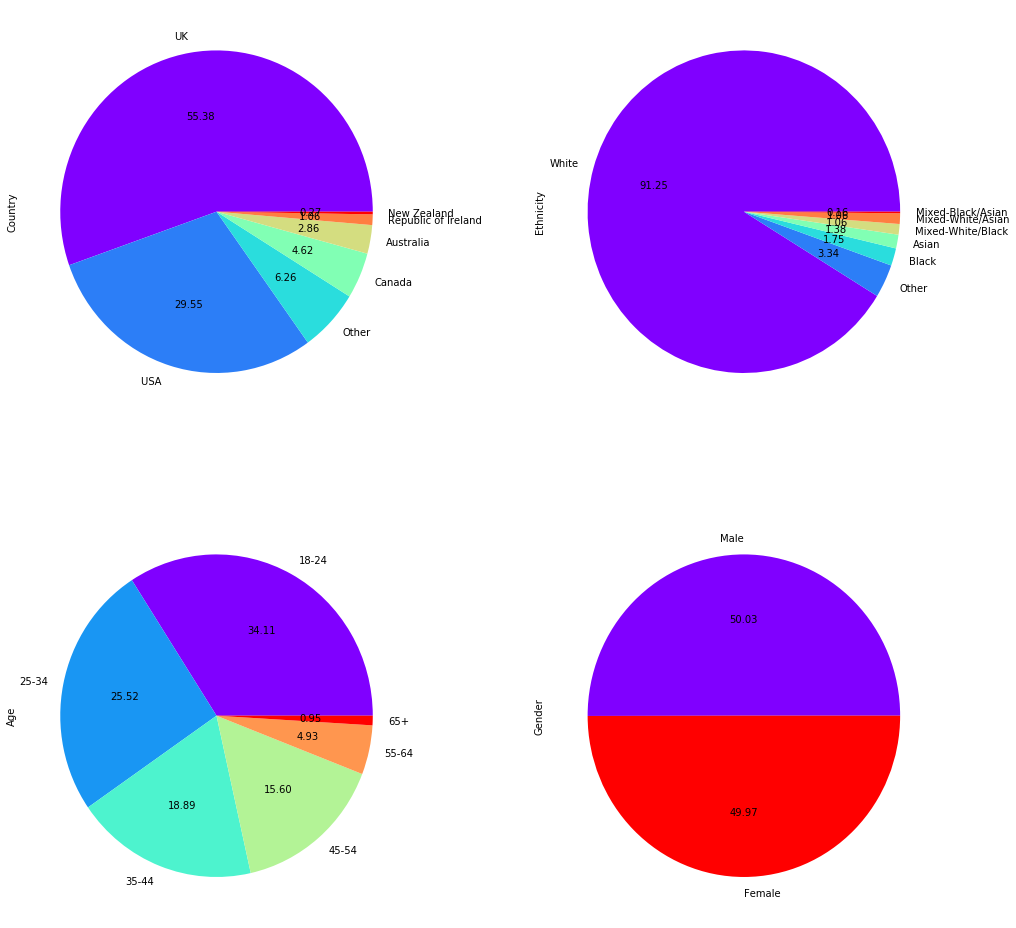

```python
plt.subplot(221)
countries = data_str['Country'].value_counts().plot(kind='pie', autopct='%.2f', figsize=(15, 15), cmap="rainbow")
plt.subplot(222)
ethnicities = data_str['Ethnicity'].value_counts().plot(kind='pie', autopct='%.2f', cmap="rainbow")
plt.subplot(223)
ages = data_str['Age'].value_counts().plot(kind='pie', autopct='%.2f', cmap="rainbow")
plt.subplot(224)
genders = data_str['Gender'].value_counts().plot(kind='pie', autopct='%.2f', cmap="rainbow")

plt.subplots_adjust(top=0.92, bottom=0.08, left=0.10, right=0.95, hspace=0.25,
                    wspace=0.35)
plt.show()
```

Looking at the 4 graphs above, there are some interesting information to note:

1. Principally, UK citizens was interviewed (more than 50%). Than US is the second most frequent state. The others are less than the 15%
2. The vast majority are White people (so Ethinicity cannot be use as a strong predictor)
3. The ranges of ages looks like well-distribuited. As predictable, the 65+ persons are fews, probably becouse it does not represent a good sample for drug addictions.
4. Fairly, the number of womans and mens interviewed is quite equal.

#### Top10 Addictions and Drugs Consumed

Here, we can find remarkable informations about the most common addictions to drugs and not only

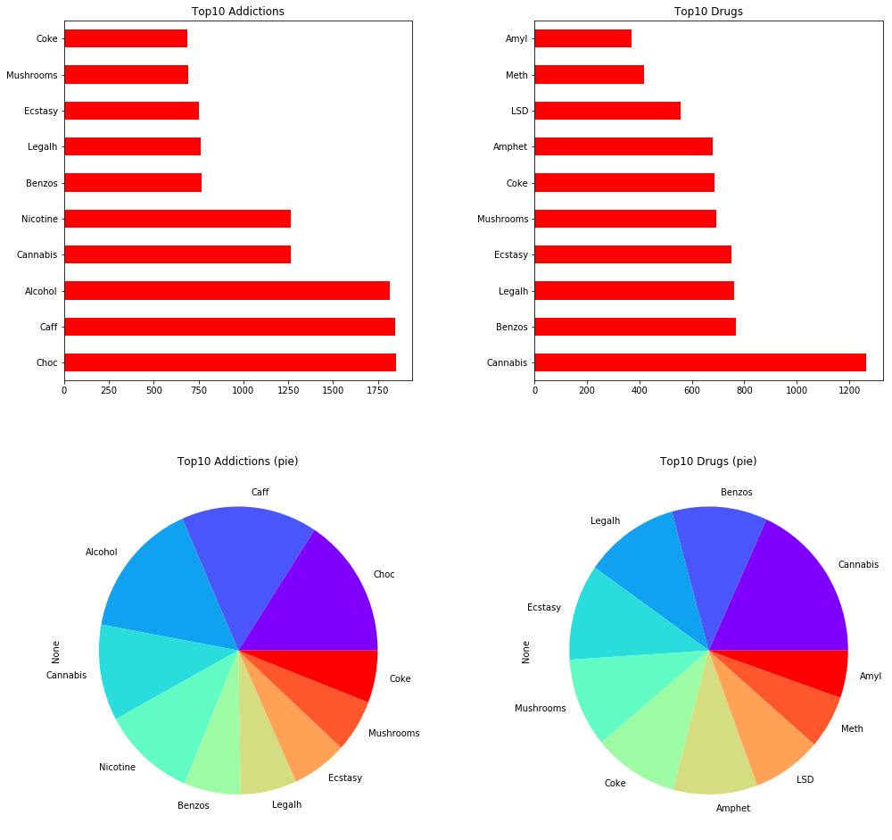

```python
addictions = ["Alcohol","Amphet","Amyl","Benzos","Caff","Cannabis","Choc" , "Coke", "Crack", "Ecstasy", "Heroin", "Ketamine", "Legalh", "LSD", "Meth", "Mushrooms", "Nicotine", "Semer", "VSA"]
drugs = ["Amphet","Amyl","Benzos","Cannabis", "Coke", "Crack", "Ecstasy", "Heroin", "Ketamine", "Legalh", "LSD", "Meth", "Mushrooms","Semer", "VSA"]


fig = plt.figure(figsize=(15,15))
add_data = data[addictions]
add_data = add_data[add_data > 1].count().sort_values(ascending=False)
add_data = add_data[:10] # TO GET THE TOP 10
add_data.rename="Top10_Addictions"
plt.subplot(221)
add_data.plot.barh(cmap="hsv",title="Top10 Addictions")

drg_data = data[drugs]
drg_data = drg_data[drg_data > 1].count().sort_values(ascending=False)
drg_data = drg_data[:10]

plt.subplot(222)
drg_data.plot.barh(cmap="hsv",title="Top10 Drugs")

plt.subplot(223)
add_data.plot.pie(cmap="rainbow",title="Top10 Addictions (pie)")
plt.subplot(224)
drg_data.plot.pie(cmap="rainbow",title="Top10 Drugs (pie)")

plt.subplots_adjust(top=0.92, bottom=0.08, left=0.10, right=0.95, hspace=0.25, wspace=0.35)
plt.show()
# addictions_stats = pd.DataFrame(clf.feature_importances_,
#                                    index = X_train.columns,
#                                     columns=['importance']
#                                   ).sort_values('importance',ascending=True)
# feature_importances.plot.barh(rot=0, figsize=(10,10), align='center')
# plt.show()
# feature_importances.describe()
```

Luckly, the most common addictions in our sample group are related to legal substances: the first 3, that represent quite the 50% of the total occurencies counted in the TOP10, are Chocolate, Caffeine and Alcohol. Then Cannabis is the most common drug (1200+/1885), remarkably similar to the people that smokes cigarettes, and the we will se Benzos (that are a particular kind of drug used also for legal treatments against psicological deseases and smoke addiction)

#### Univariate Plot

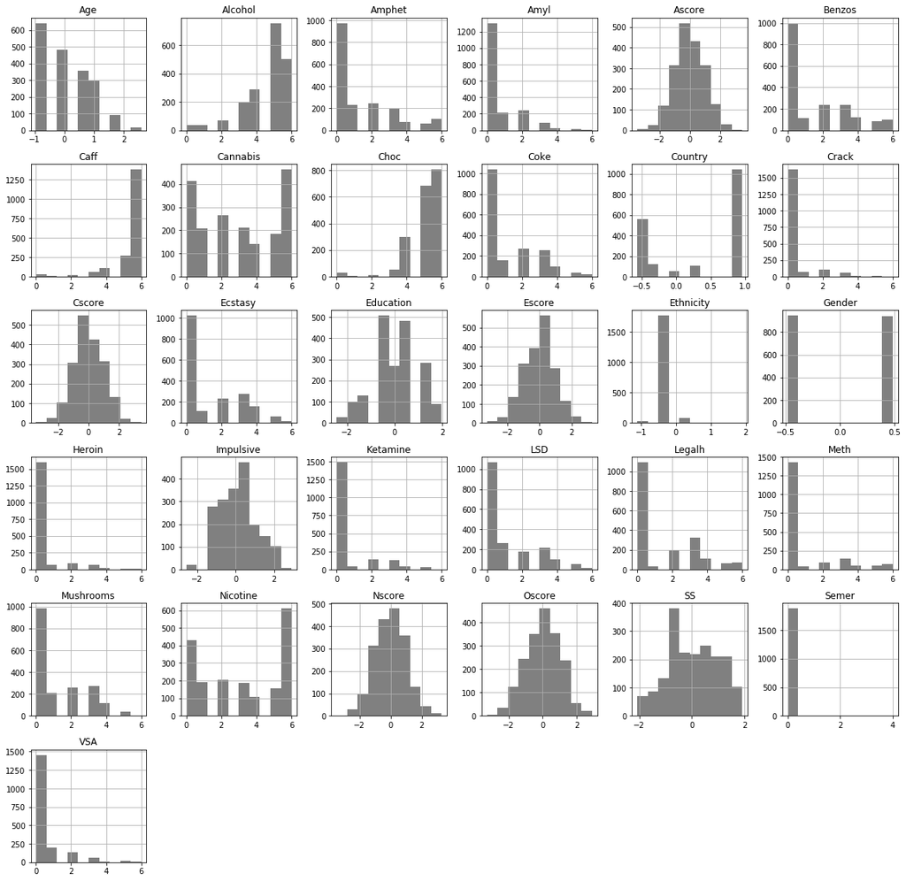

```python
hist = data.drop("ID",axis=1).hist(figsize=(20,20),facecolor='grey')
```

#### 1.5 Heatmap Correlation Plot

Here we can see the **Heatmap Correlation Plot**, means an heatmap that represent the value of correlation measured for each couple of feature of our dataset. Obviously, the upper-right part is equally to the lower-left one, splitted by the "1" diagonal that is the correlation of each feature with itself.

**Correlation** is a statistical term which in common usage refers to how close two variables are to having a linear relationship with each other. For example, two variables which are linearly dependent (say, x and y which depend on each other as x = 2y) will have a higher correlation than two variables which are non-linearly dependent (say, u and v which depend on each other as u = v2).

Specifically, **Pearson Correlation** is defined as:

$$ \text{Cor}(X,Y) = \frac{{}\sum_{i=1}^{n} (x_i - \overline{x})(y_i - \overline{y})} {{\sqrt{\sum_{i=1}^{n} (x_i - \overline{x})^2}}{\sqrt{\sum_{i=1}^{n}(y_i - \overline{y})^2}}} $$

The values of the correlation coefficient can range from -1 to +1. The closer it is to +1 or -1, the more closely are the two variables are related. The positive sign signifies the direction of the correlation i.e. if one of the variables increases, the other variable is also supposed to increase, otherwise if the sign is negative, the trend is opposite.

Features with high correlation are more linearly dependent and hence have almost the same effect on the dependent variable. **So, when two features have high correlation, eventually we can drop one of the two features.** Meanwhile, looking at the class choosen for classification, the correlated features will be the ones more usefull for our estimator, so it is a way to display the **importance of a determinated predictor knowing the prediction goal**.

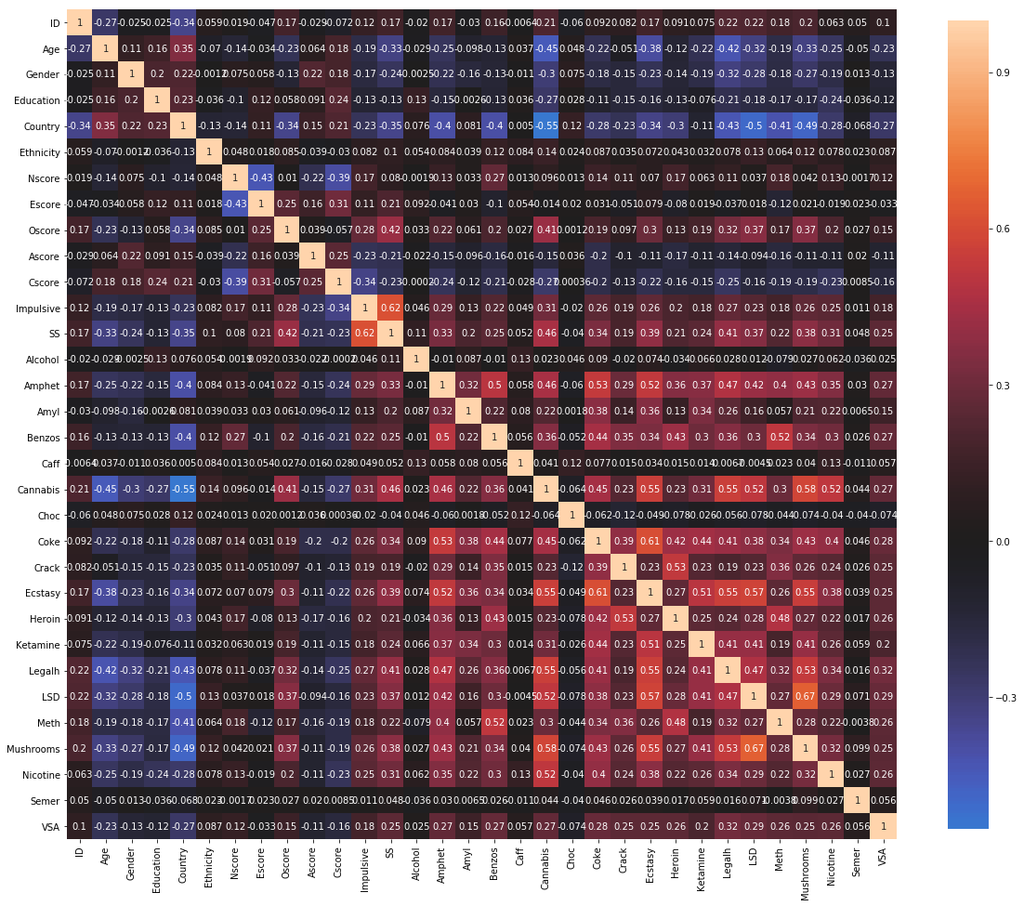

```python
# Compute the correlation matrix
corr = data.corr()
# Set up the matplotlib figure
f, ax = plt.subplots(figsize=(20, 20))
# Generate a custom diverging colormap
cmap = sns.diverging_palette(220, 10, as_cmap=True)
# Draw the heatmap with the mask and correct aspect ratio

colors = ["dusty purple", "red","amber"]

sns.heatmap(corr, center=0,annot=True,# cmap=cmap,
            square=True, linewidths=0, cbar_kws={"shrink": .8})
plt.show()
```

This *correlogram* give us the possibility to deeply understand correlation between variables: it is so important to understand if two variable are strongly correlated, becouse their contribute to classification is strongly bounded, and we can keep just one of two of these without loosing too accuracy for the model. Looking at the graph, the attention goes quickly to the right-low area of the correlation matrix, that is most red-painted that the rest of the square: this area is formed by the correlation of "hard drugs" features, so our simple interpretation is that the consumption of these drugs goes parallely and when your are, for example, an Ecstasy Consumer, the risk to fall in addiction with other drugs (particularly LSD, or Mushrooms) is greater. As reported in other scientific articles, Correlation analysis demonstrated the existence of groups of drugs with strongly correlated consumption patterns. Three correlation pleiades were identified, named by the central drug in the pleiade: ecstasy, heroin, and benzodiazepines pleiades.

### Univariate Regression based on Mushrooms

The high grade of correlation between Mushrooms and LSD is an indicator of the strong relation between the two variable: so it could be meaningfull trying to predict an LSD addicted by his grade of usage of LSD: so let's try to look the **univariate regression** between the two:

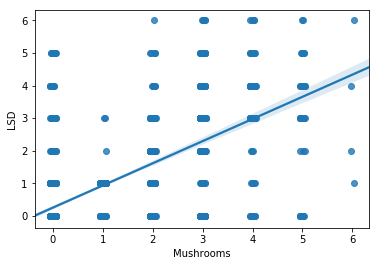

```python
sns.regplot(x='Mushrooms',y='LSD',data=data,marker="o",x_jitter=.06)
```

This represent the best approximation of a linear relation between Mushrooms (axes) and LSD (ordinates), it doesn't fit the problem so good and the errors are well described by graph, but correlation between two make this result not totally trivial. Evidently, there are better methods to make predictions, and we will see it in details.

### Clustermap

Finally let's see the **Cluster map**, that sostantially plot a matrix dataset as a hierarchically-clustered heatmap. **Clustering** refers to a very broad set of techinques for finding subgroups, or cluster, in a dataset. The clusters are made by defining groups of *nearest* elements: so it is necessary to define a *similarity measure* () **Hierarchichal clustering** is an alternative to prototyope-based clustering algorithms. The main advantage of Hierarchichal clustering is that we do not need to specify the number of clusters, it will find it by itself. In addition, it enables the plotting of dendograms. Dendograms are visualizations of a binary hierarchichal clustering.

Let's move our attention to the upper dendogram. Becouse of the measure choosen (**correlation**) graph is so related to the correlation matrix seen before: as the one above, here we can see relation between features and how its will be used in a hierarchical clustering. So it is natural that **the first relations between two features are ever with the most correlated one**; that's becouse the metric choosen, that is correlation (but, honestly, it doesn't change for euclidean distance measure).

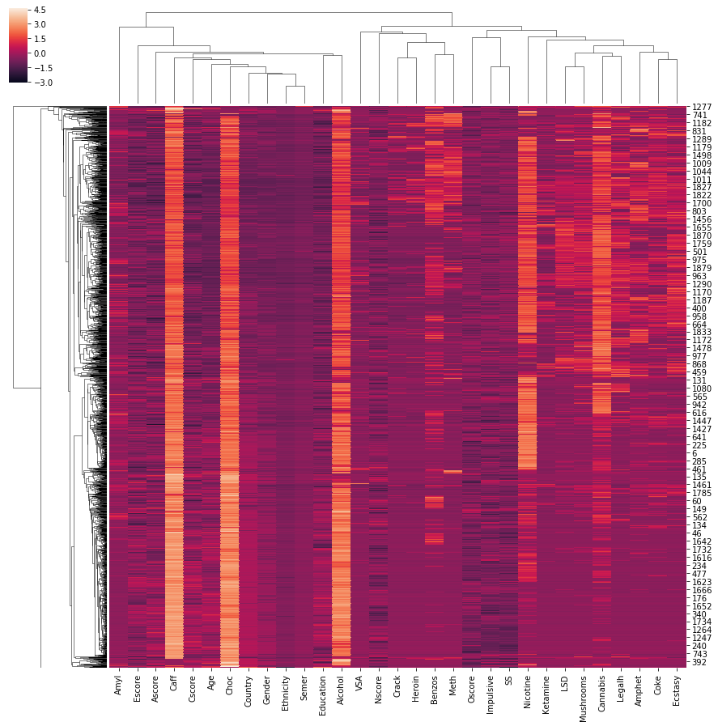

```python
if "ID" in data.columns : data = data.drop(["ID"],axis=1)
g = sns.clustermap(data,figsize=(15,15),metric="correlation",z_score=0)
plt.show()
```

## ML Beginning Analysis

Dataset provides **19 different classes** to be goal of prediction: **Alcohol, Amphet, Amyl, Benzos, Caff, Cannabis, Choc, Coke, Crack, Ecstasy, Heroin, Ketamine, Legalh, LSD, Meth, Mushrooms, Nicotine, Semer, VSA.**

Possible approaches for classification are:

- Seven class classifications for each drug separately.
- Problem can be transformed to binary classification by union of part of classes into one new class. For example, "Never Used", "Used over a Decade Ago" form class "Non-user" and all other classes form class "User".
- The best binarization of classes for each attribute.
- Evaluation of risk to be drug consumer for each drug.

### Classification Problem Definition

So, we have to define our classification problem, by choosing a class to be object of our prediction, and in which form it will be given, depending on the classification algorithm it will provides.